# Week 3/4 Homework

Arin Vansomphone

2022-07-15

### 1. Importing the datasets:

```r
# loading the packages
library(tidyverse)
library(here)
library(gapminder)

# importing the datasets
demoinfo <- read_csv("accord_key.csv")
bloodpress <- read_csv("bloodpressure.csv")
bloodsugar <- read_csv("hba1c.csv")
```

### 2. Describing the datasets

```r
demoinfo %>%
  group_by(female) %>%
  summarize(number = n(),
            percent = 100 *number / 10251)
```

```
## # A tibble: 2 × 3
##   female number percent
##    <dbl>  <int>   <dbl>
## 1      0   6299    61.4
## 2      1   3952    38.6
```

The database population is roughly 61.4% male and 38.6% female.

Grouping by ethnicity now:

```r
demoinfo %>%
  group_by(raceclass) %>%
  summarize(number = n(),
            percentage = 100 * number / 10251)
```

```
## # A tibble: 4 × 3
##   raceclass number percentage
##   <chr>      <int>      <dbl>
## 1 Black       1953      19.1
## 2 Hispanic     737       7.19
## 3 Other       1168      11.4
## 4 White       6393      62.4
```

The database consists of around 19.1% Black people, 7.2% Hispanic people, 11.4% Other people, and 62.4% White people.

2. To find the mean and interquartile numbers for the blood pressure and sugar of each individual, we need to use the summarize function again.

```r
# blood pressure numbers
bloodpress %>%
  group_by(MaskID) %>%
  summarize(mean = mean(sbp),
            IQR = IQR(sbp))
```

```
## # A tibble: 10,249 × 3
##    MaskID  mean   IQR
##     <dbl> <dbl> <dbl>
##  1 100001  117. 10
##  2 100002  123. 10
##  3 100003  135. 21
##  4 100004  117   6.5
##  5 100005  144. 10.8
##  6 100006  126. 11
##  7 100007  112. 21
##  8 100008  136. 11.5
##  9 100009  121. 17
## 10 100010  134.  9.75
## # … with 10,239 more rows
```

```r
# blood sugar numbers
bloodsugar %>%
  group_by(MaskID) %>%
  summarize(mean = mean(hba1c),
            IQR = IQR(hba1c))
```

```
## # A tibble: 10,245 × 3
##    MaskID  mean   IQR
##     <dbl> <dbl> <dbl>
##  1 100001  7.82 0.625
##  2 100002  6.26 0.350
##  3 100003  6.81 0.150
##  4 100004  8    0.500
##  5 100005  7.6  1.00
##  6 100006  7.16 0.625
##  7 100007  6.51 0.375
##  8 100008  9.06 1.00
##  9 100009  7.15 0.850
## 10 100010  7.11 0.425
## # … with 10,235 more rows
```

### 3. Extracting baseline SBP, DBP, and hba1c numbers

To extract summary stats on the baseline SBP, DBP, and hba1c numbers, we input `filter(Visit == "BLR")` into our piped function.

Baseline SBP:

```r
bloodpress %>%
  filter(Visit == "BLR") %>%
  summarise(mean = mean(sbp),
            std = sd(sbp),
            IQR = IQR(sbp),
            median = median(sbp))
```

```
## # A tibble: 1 × 4
##    mean   std   IQR median
##   <dbl> <dbl> <dbl>  <dbl>
## 1  136.  17.1    22    135
```

Baseline DBP:

```r
bloodpress %>%
  filter(Visit == "BLR") %>%
  summarise(mean = mean(dbp),
            std = sd(dbp),
            IQR = IQR(dbp),
            median = median(dbp))
```

```
## # A tibble: 1 × 4
##    mean   std   IQR median
##   <dbl> <dbl> <dbl>  <dbl>
## 1  74.9  10.7    14     75
```

Baseline hba1c:

```r
bloodsugar %>%
  filter(Visit == "BLR") %>%
  summarise(mean = mean(hba1c),
            std = sd(hba1c),
            IQR = IQR(hba1c),
            median = median(hba1c))
```

```
## # A tibble: 1 × 4
##    mean   std   IQR median
##   <dbl> <dbl> <dbl>  <dbl>
## 1  8.30  1.06   1.3    8.1
```

Now that we’ve found the numbers for the entire population, let’s find the summary stats for select groups of the population. To do this, we need to merge the `bloodpress` and `bloodsugar` dataframes into the `demoinfo` dataframe so we can have the ethnicity and gender information.

```r
bigdataset <- demoinfo %>%
  inner_join(bloodpress, by = "MaskID")

bigdataset <- bigdataset %>%
  inner_join(bloodsugar, by = "MaskID")
```

Let’s first find the summary stats based on gender: SBP:

```r
bigdataset %>%
  filter(Visit.x == "BLR") %>%
  group_by(female) %>%
  summarize(mean = mean(sbp),
            std = sd(sbp),
            median = median(sbp),
            IQR = IQR(sbp))
```

```
## # A tibble: 2 × 5
##   female  mean   std median   IQR
##    <dbl> <dbl> <dbl>  <dbl> <dbl>
## 1      0  136.  16.4    135    21
## 2      1  137.  17.7    136    23
```

DBP:

```r
bigdataset %>%
  filter(Visit.x == "BLR") %>%
  group_by(female) %>%
  summarize(mean = mean(dbp),
            std = sd(dbp),
            median = median(dbp),
            IQR = IQR(dbp))
```

```
## # A tibble: 2 × 5
##   female  mean   std median   IQR
##    <dbl> <dbl> <dbl>  <dbl> <dbl>
## 1      0  74.7  10.6     75    14
## 2      1  75.2  10.5     75    14
```

hba1c:

```r
bigdataset %>%
  filter(Visit.y == "BLR") %>%
  group_by(female) %>%
  summarize(mean = mean(hba1c),
            std = sd(hba1c),
            median = median(hba1c),
            IQR = IQR(hba1c))
```

```
## # A tibble: 2 × 5
##   female  mean   std median   IQR
##    <dbl> <dbl> <dbl>  <dbl> <dbl>
## 1      0  8.28  1.04    8.1  1.20
## 2      1  8.34  1.07    8.1  1.3
```

Now based on ethnicity: SBP:

```r
bigdataset %>%
  filter(Visit.x == "BLR") %>%
  group_by(raceclass) %>%
  summarize(mean = mean(sbp),
            std = sd(sbp),
            median = median(sbp),
            IQR = IQR(sbp))
```

```
## # A tibble: 4 × 5
##   raceclass  mean   std median   IQR
##   <chr>     <dbl> <dbl>  <dbl> <dbl>
## 1 Black      139.  17.6    137    23
## 2 Hispanic   137.  16.8    136    22
## 3 Other      137.  15.4    137    19
## 4 White      136.  16.9    135    22
```

DBP:

```r
bigdataset %>%
  filter(Visit.x == "BLR") %>%
  group_by(raceclass) %>%
  summarize(mean = mean(dbp),
            std = sd(dbp),
            median = median(dbp),
            IQR = IQR(dbp))
```

```
## # A tibble: 4 × 5
##   raceclass  mean   std median   IQR
##   <chr>     <dbl> <dbl>  <dbl> <dbl>
## 1 Black      76.5 10.4      76    14
## 2 Hispanic   75.1 11.1      76    14
## 3 Other      76.0  9.98     76    12
## 4 White      74.2 10.6      74    14
```

hba1c:

```r
bigdataset %>%
  filter(Visit.y == "BLR") %>%
  group_by(raceclass) %>%
  summarize(mean = mean(hba1c),
            std = sd(hba1c),
            median = median(hba1c),
            IQR = IQR(hba1c))
```

```
## # A tibble: 4 × 5
##   raceclass  mean   std median   IQR
##   <chr>     <dbl> <dbl>  <dbl> <dbl>
## 1 Black      8.52 1.16     8.3  1.50
## 2 Hispanic   8.50 1.20     8.3  1.50
## 3 Other      8.30 1.11     8.1  1.4
## 4 White      8.22 0.976    8    1.2
```

### 4. Understanding the trend of SBP, DBP, and hba1c over visits

```r
bloodpress %>%
  group_by(Visit) %>%
  summarize(meanSBP = mean(sbp))
```

```
## # A tibble: 46 × 2
##    Visit meanSBP
##    <chr>   <dbl>
##  1 BLR      136.
##  2 EXIT     129.
##  3 F01      132.
##  4 F02      126.
##  5 F03      125.
##  6 F04      129.
##  7 F06      123.
##  8 F08      129.
##  9 F10      121.
## 10 F12      129.
## # … with 36 more rows
```

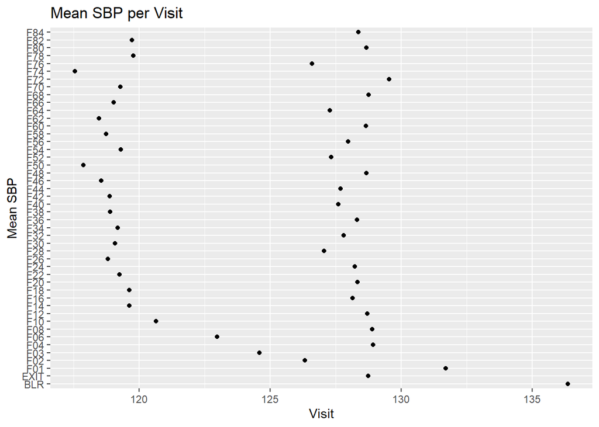

```r
bloodpress %>%
  group_by(Visit) %>%
  summarize(meanSBP = mean(sbp)) %>%
  ggplot(aes(x = Visit, y = meanSBP)) +
  geom_point() +
  coord_flip() +
  labs(title = "Mean SBP per Visit",
       x = "Mean SBP",
       y = "Visit")
```

4. Repeating the procedure for DBP and hba1c: DBP:

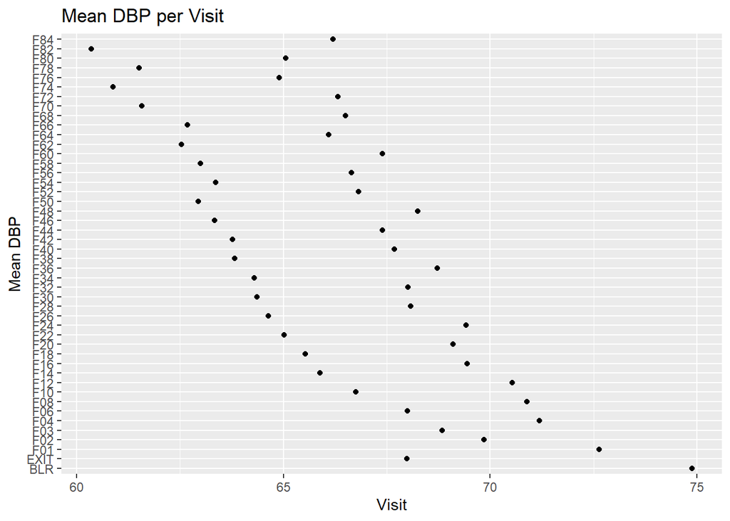

```r
bloodpress %>%
  na.omit() %>%
  group_by(Visit) %>%
  summarize(meanDBP = mean(dbp)) %>%
  ggplot(aes(x = Visit, y = meanDBP)) +
  geom_point() +
  coord_flip() +
  labs(title = "Mean DBP per Visit",
       x = "Mean DBP",
       y = "Visit")
```

hba1c:

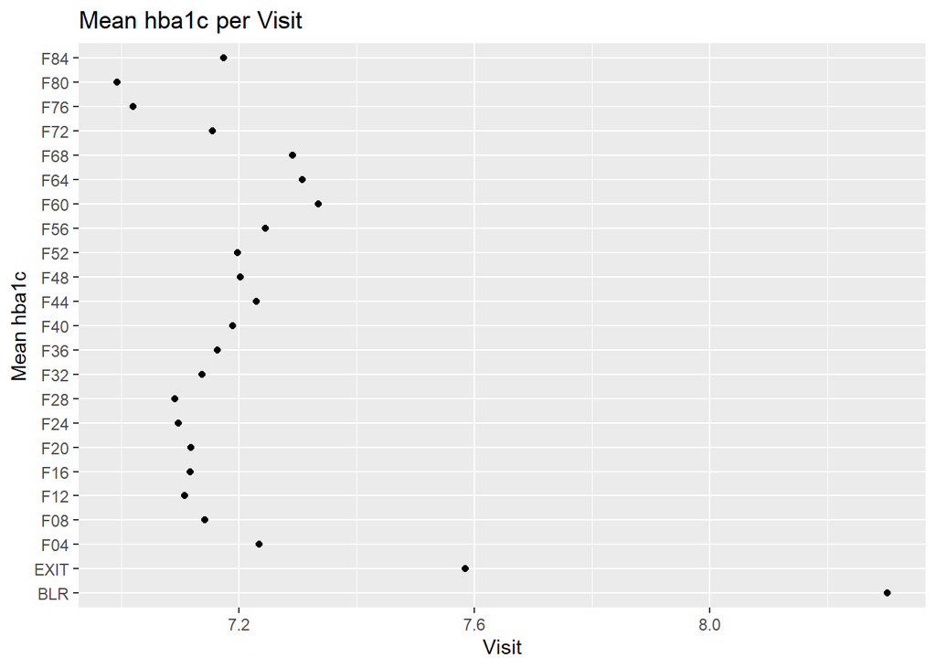

```r
bloodsugar %>%
  na.omit() %>%
  group_by(Visit) %>%
  summarize(meanhba1c = mean(hba1c)) %>%
  ggplot(aes(x = Visit, y = meanhba1c)) +
  geom_point() +
  coord_flip() +
  labs(title = "Mean hba1c per Visit",
       x = "Mean hba1c",
       y = "Visit")
```

### 5. Bonus

For the bonus we need to create a new variable named “glycemic_arm” that sorts the arm types into 2 categories. To accomplish this we will create a set of values corresponding to each type of glycemic arm and ask R to assign values based on the set.

```r
# converting arm to character type and creating values for 0
bigdataset$arm <- as.character(bigdataset$arm)
glycemicarm0 = c("1", "2", "5", "6")

# creating the new variable and assigning values
bigdataset$glycemic_arm = "1"
bigdataset$glycemic_arm[bigdataset$arm %in% glycemicarm0] = "0"
```

Plotting the mean profile plot grouped by glycemic arm is nearly the same as we did previously:

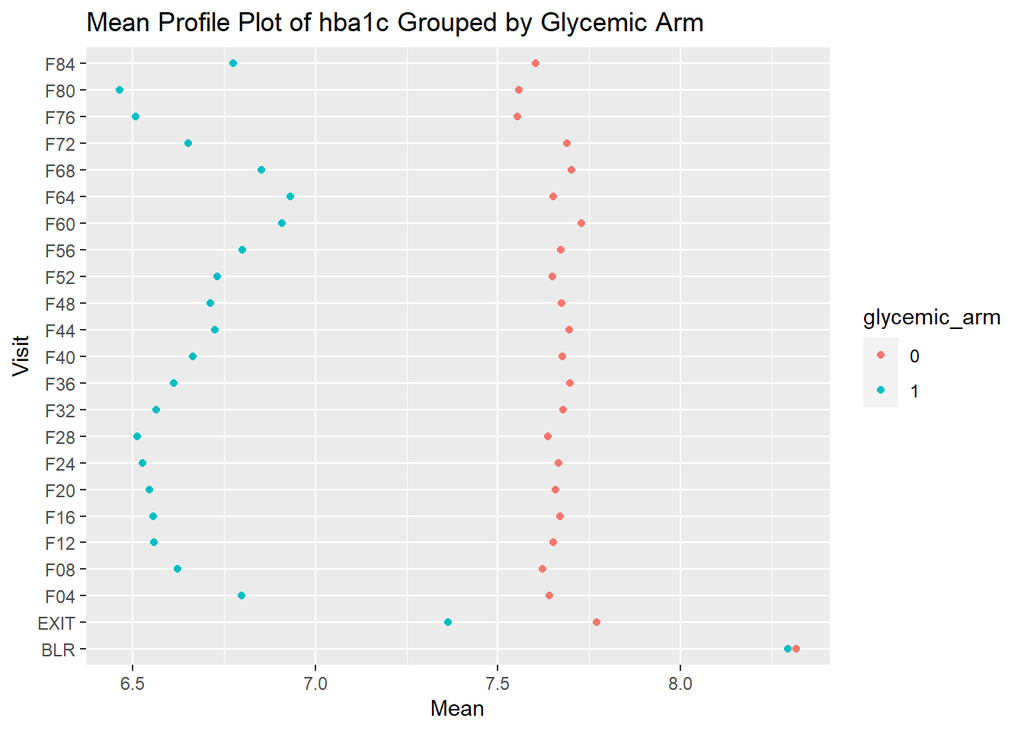

```r
bigdataset %>%
  group_by(Visit.y, glycemic_arm) %>%
  summarize(mean = mean(hba1c)) %>%
  ggplot(aes(x = Visit.y, y = mean, color = glycemic_arm)) +
  geom_point() +
  coord_flip() +
  labs(title = "Mean Profile Plot of hba1c Grouped by Glycemic Arm",
       x= "Visit",
       y = "Mean")
```